# Bacterial diversity in groundwater samples

Pierre-Yves Dupont

July 27, 2018

## Libraries

```r
library(phyloseq); packageVersion("phyloseq")
```

```
## [1] '1.26.1'
```

```r
library(tidyverse)
library(caching); packageVersion("caching")
```

```
## [1] '0.1.9'
```

```r
library(cowplot)
library(assertthat)
library(ggplot2)
library(RColorBrewer)
library(colorRamps)
library(ggrepel)
require(car)
library(ggpubr)
library(Polychrome)
```

## Loading data

The objects computed using DADA2 have been saved using the `caching` library and can be loaded using the same library. Here we can load the `phyloseq` object `ps` and the `data.frame` extracted from it `taxa.dt`.

```r
ps <- load.object("psc")$orig
if(object.cached("taxa.dt")){
  taxa.dt <- load.object("taxa.dt")
} else{
  taxa.dt <- psmelt(ps)
  save.object(taxa.dt)
}
```

## Loading Metadata

```r
metadata <- read_tsv("samples-metadata.tsv")
metadata.df <- as.data.frame(metadata)
rownames(metadata.df) <- metadata$SampleID
sample_data(ps) <- metadata.df
if(!exists("taxa.dt")){
  taxa.dt <- psmelt(ps)
  save.object(taxa.dt)
}
```

## Separate UC samples

```r
uc_samples <- c("GW180247","GW180419","GW180420","GW180421","GW180422","GW180423","GW180424","GW180425","GW180426","GW180427","GW180428", "GW1801011A", "GW180248")
ps_uc <- prune_samples(sample_data(ps)$SampleID %in% uc_samples, ps)
```

## Diversity plots

### Filter low abundance taxa.

```r
aggregation.level <- 'Genus'

dt <- taxa.dt %>% filter(Blank == "No", SampleID %in% uc_samples)
top <- dt %>%
  group_by(!!(rlang::sym(aggregation.level))) %>%
  summarise(Abundance=sum(Abundance)) %>%
  mutate(AbundanceRel = Abundance/sum(Abundance)) %>%
  filter(AbundanceRel >= 0.01)
top <- top[[aggregation.level]]
```

### Compute relative abundance

```r
dt.grouped <- dt %>%
  filter(!!(rlang::sym(aggregation.level)) %in% top)  %>%
  mutate(!!(rlang::sym(aggregation.level)) := factor(!!(rlang::sym(aggregation.level)), levels=unique(!!(rlang::sym(aggregation.level))))) %>%
  filter(!is.na(!!(rlang::sym(aggregation.level)))) %>% # Remove NA
  group_by(SampleID, !!(rlang::sym(aggregation.level))) %>%
  summarize(Abundance = sum(Abundance)) %>%
  mutate(Abundance = Abundance/sum(Abundance) * 100) %>%
  filter(!is.na(!!(rlang::sym(aggregation.level))))
```

### Set the palette

```r
colourCount <- length(unique(as.character(dt.grouped[[aggregation.level]])))
palette <- colorRampPalette(brewer.pal(10,"Paired"))(colourCount)
```

### Plot

#### All samples

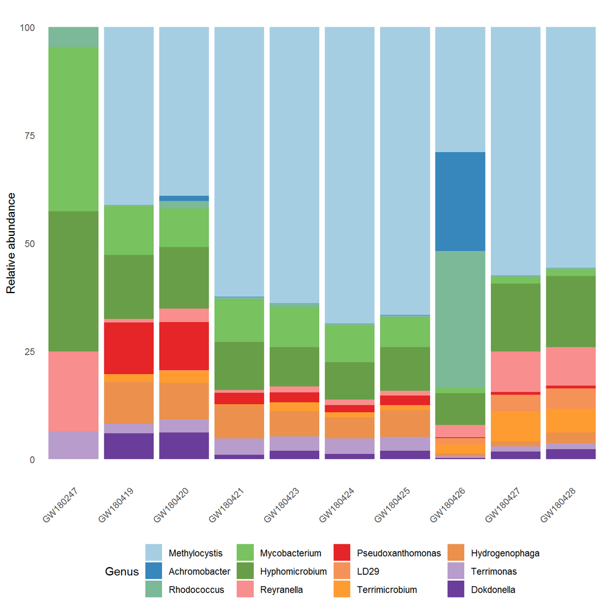

```r
ggplot(dt.grouped, aes(SampleID, Abundance, fill = !!(rlang::sym(aggregation.level)))) +
  geom_bar(stat = "identity", position = "stack") +
  # facet_wrap(~SampleTypeAnalysed, ncol = 1, scales = "free_x") +
  theme_minimal() +
  scale_fill_manual(values = palette) +
  xlab(NULL) +
  ylab("Relative abundance") +
  theme(axis.text.x = element_text(angle = 45, hjust = 1)) +
  theme(panel.grid.major = element_blank(), panel.grid.minor = element_blank(), panel.background = element_blank()) +
  theme(legend.position="bottom")
```

#### Only 3 samples

The following code builds a plot using the same taxa set as for the complete plot by subsetting the `dt.grouped` data.frame. This doesn’t change the distribution of the taxa.

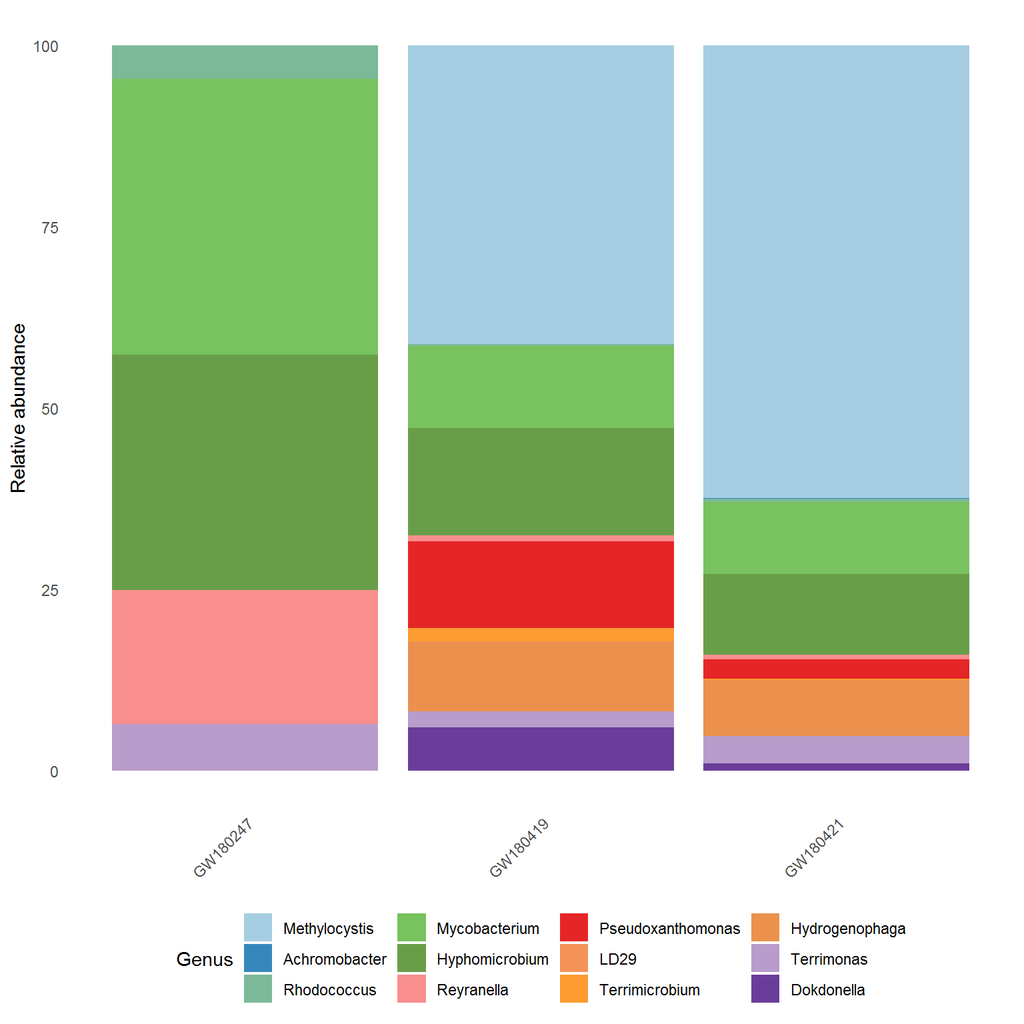

```r
dt.grouped <- dt.grouped %>% filter(SampleID %in% c("GW180247", "GW180419", "GW180421"))
ggplot(dt.grouped, aes(SampleID, Abundance, fill = !!(rlang::sym(aggregation.level)))) +
  geom_bar(stat = "identity", position = "stack") +
  # facet_wrap(~SampleTypeAnalysed, ncol = 1, scales = "free_x") +
  theme_minimal() +
  scale_fill_manual(values = palette) +
  xlab(NULL) +
  ylab("Relative abundance") +
  theme(axis.text.x = element_text(angle = 45, hjust = 1)) +
  theme(panel.grid.major = element_blank(), panel.grid.minor = element_blank(), panel.background = element_blank()) +
  theme(legend.position="bottom")
```

The following code first subset the data then recomputes the taxa and build the abundance plot.

```r
dt <- taxa.dt %>%
  filter(Blank == "No", SampleID %in% uc_samples) %>%
  filter(SampleID %in% c("GW180247", "GW180419", "GW180421"))

top <- dt %>%
  group_by(!!(rlang::sym(aggregation.level))) %>%
  summarise(Abundance=sum(Abundance)) %>%
  mutate(AbundanceRel = Abundance/sum(Abundance)) %>%
  filter(AbundanceRel >= 0.01)
top <- top[[aggregation.level]]

dt.grouped <- dt %>%
  filter(!!(rlang::sym(aggregation.level)) %in% top)  %>%
  mutate(!!(rlang::sym(aggregation.level)) := factor(!!(rlang::sym(aggregation.level)), levels=unique(!!(rlang::sym(aggregation.level))))) %>%
  filter(!is.na(!!(rlang::sym(aggregation.level)))) %>% # Remove NA
  group_by(SampleID, !!(rlang::sym(aggregation.level))) %>%
  summarize(Abundance = sum(Abundance)) %>%
  mutate(Abundance = Abundance/sum(Abundance) * 100) %>%
  filter(!is.na(!!(rlang::sym(aggregation.level))))

colourCount <- length(unique(as.character(dt.grouped[[aggregation.level]])))
palette <- colorRampPalette(brewer.pal(10,"Paired"))(colourCount)
```

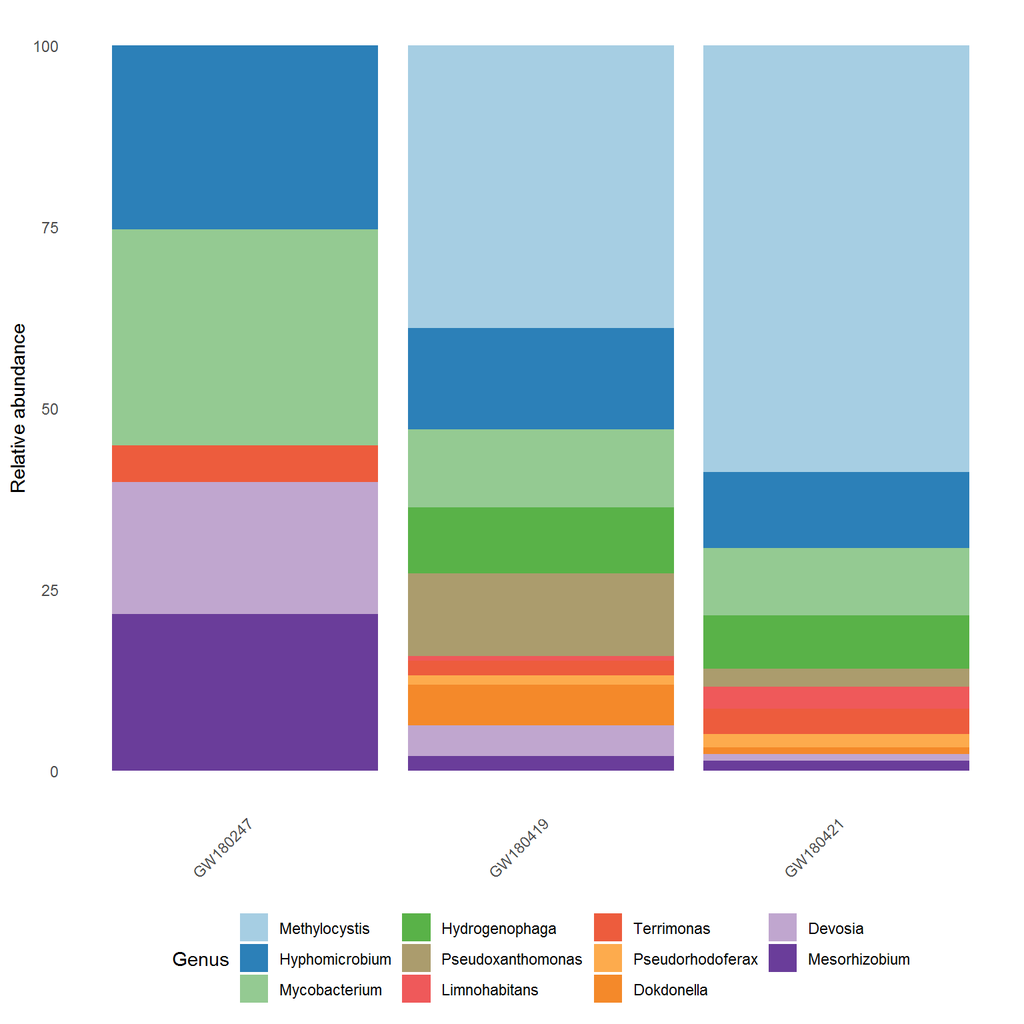

```r
ggplot(dt.grouped, aes(SampleID, Abundance, fill = !!(rlang::sym(aggregation.level)))) +
  geom_bar(stat = "identity", position = "stack") +
  # facet_wrap(~SampleTypeAnalysed, ncol = 1, scales = "free_x") +
  theme_minimal() +
  scale_fill_manual(values = palette) +
  xlab(NULL) +
  ylab("Relative abundance") +
  theme(axis.text.x = element_text(angle = 45, hjust = 1)) +
  theme(panel.grid.major = element_blank(), panel.grid.minor = element_blank(), panel.background = element_blank()) +
  theme(legend.position="bottom")
```

Both plots are correct. The first one corresponds to the distribution of the taxa identified as the most abundant in all the samples while the second corresponds to the distribution of the the most abundant taxa in these three samples. It is not surpising to see that you have such a large difference between the plots because your conditions (and likely your communities) are very different.

#### Top 5 taxa per sample

If you want to get the top `N` taxa per samples, you need to first group by your `Samples` and taxa then select the `top_n` values based on the `Abundance`. You can change the `N` value if you want more or less taxa.

```r
N <- 5
dt <- taxa.dt %>%
  filter(Blank == "No", SampleID %in% uc_samples)

dt.grouped <- dt %>%
  mutate(!!(rlang::sym(aggregation.level)) := factor(!!(rlang::sym(aggregation.level)), levels=unique(!!(rlang::sym(aggregation.level))))) %>%
  filter(!is.na(!!(rlang::sym(aggregation.level)))) %>% # Remove NA
  group_by(SampleID, !!(rlang::sym(aggregation.level))) %>%
  summarize(Abundance = sum(Abundance)) %>%
  mutate(Abundance = Abundance/sum(Abundance) * 100) %>%
  top_n(5, Abundance) %>%
  filter(!is.na(!!(rlang::sym(aggregation.level))))
```

I also use a different palette because there too many different values for the one that you were using (they are almost impossible to differentiate). The library `Polychrome` as to be installed first using `install.packages("Polychrome")`.

```r
colourCount <- length(unique(as.character(dt.grouped[[aggregation.level]])))
# palette <- colorRampPalette(brewer.pal(10,"Paired"))(colourCount)
palette <- as.character(palette36.colors(colourCount))
```

The plot part doesn’t change.

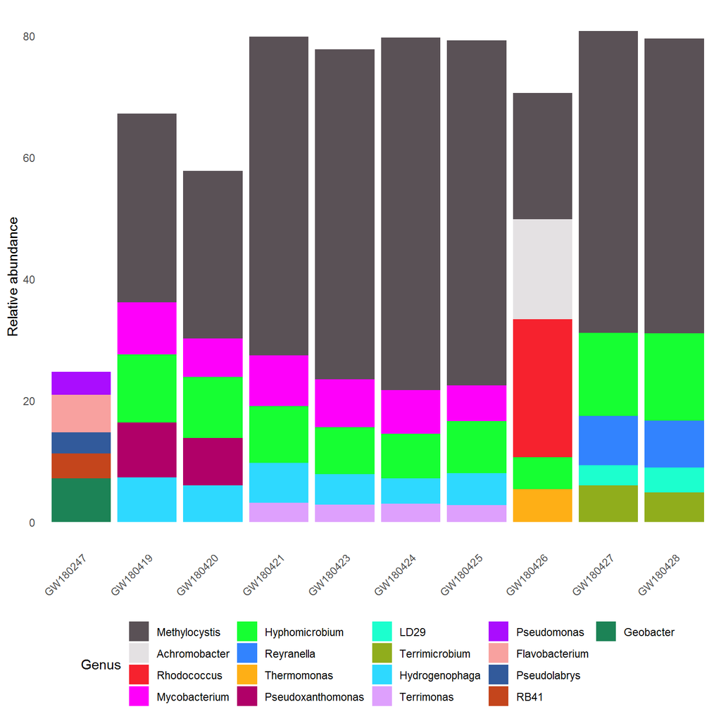

```r
ggplot(dt.grouped, aes(SampleID, Abundance, fill = !!(rlang::sym(aggregation.level)))) +
  geom_bar(stat = "identity", position = "stack") +
  # facet_wrap(~SampleTypeAnalysed, ncol = 1, scales = "free_x") +
  theme_minimal() +
  scale_fill_manual(values = palette) +
  xlab(NULL) +
  ylab("Relative abundance") +
  theme(axis.text.x = element_text(angle = 45, hjust = 1)) +
  theme(panel.grid.major = element_blank(), panel.grid.minor = element_blank(), panel.background = element_blank()) +
  theme(legend.position="bottom")
```